# Reproducible Report of Thesis Analyses

This page hosts the reproducible analyses of Jeff Kravitz’s thesis research in the Experimental Psychology program at CUNY Brooklyn College. This page also serves as the completion of the midterm assignment for PSYC7709 *Using R for Reproducible Research*. Further information about the thesis research can be found in the registration document titled “Moral Licensing Registration.docx”, located in the associated git repository.

# Introduction

This report contains the analyses of an unpublished study by Kravitz and Chapman (2018).  
This study focuses on the distinct social functions of moral disgust and moral anger. Specifically, I theorize that disgust, a withdrawal-tendency emotion, has evolved to function in the social domain by causing us to withdraw from people with stable, negative traits, thus minimizing the negative impact on ourselves. In contrast, anger, an approach-tendency emotion, causes us to engage with people who have transgressed against us, placing us in immediate precarious situations but maximizing positive outcomes in the future.

In order to test this hypothesis, 212 participants sampled from Amazon’s Mechanical Turk completed an online survey programmed using Qualtrics software. All participants read a fabricated “news artcle” describing a high school principal who either sexually harassed a waitress or was pulled over by a cop for using cocaine (counterbalanced). To manipulate moral character of a transgessor, one independent variable of Domain (Different vs. Control vs. Same) was used. Participants in the “Different Domain” condition first read a fabricated “news article” that described the principal’s benevolant actions in a domain other than that in which he transgressed (e.g., a principal who campaigned against drug use was caught harassing a woman, and vise versa). Participants in the “Same Domain” condition first read a fabricated “news article” that described the principal’s benevolant actions in the same domain in which he transgressed (e.g., a principal who campaigned against drug use was pulled over for using cocaine, and vise versa). Participants in the “Control” condition did not read any article about the principal’s benevolant actions. The principal who committed a transgression in a different domain should be rated as having better character than the principal who did not have any benevolant actions (control). The principal who committed a trangression in the same domain should have worse character than principal who did not have any benevolant actions (control) due to the added effect of hypocrisy.

Participants completed measures on 6 dependent variables: (1) Act Judgments of the principal, (2) Character Judgments of the principal, (3) Emotion towards the principal in endorsements of words, (4) Emotion towards the principal in endorsement of photographed faces, (5) Hypocrisy Judgments of the principal, and (6) Disgust-Scale Ratings.

# Re-Analyses

### Loading/cleaning data

```r
# Loading data into R

library(readxl)
Final_CharExp1_Data <- read_excel("Final_CharExp1_Data.xls")

library(dplyr)
charExp1 <- Final_CharExp1_Data %>%
  filter(Final_CharExp1_Data$Finished==1,
         Final_CharExp1_Data$Attention_Check==1,
         Final_CharExp1_Data$DSR_Attention_Check==1,
         Final_CharExp1_Data$Half_Median_Time==1)

charExp1$Domain <- factor(charExp1$Domain, levels = unique(charExp1$Domain))
```

### Cronbach’s alphas

```r
library(psych)

# Cronbach's - Act judgments
cron_act_judgments <- data.frame(charExp1$Punishment,
                            charExp1$Wrongness,
                            charExp1$Blame)
cron_act_judgments <- psych::alpha(cron_act_judgments)
# Cronbach's - Character judgments
cron_char_judgments <- data.frame(charExp1$Good_vs_Bad_Person,
                             charExp1$Moral_Standards,
                             charExp1$Trustworthiness)
cron_char_judgments <- psych::alpha(cron_char_judgments)
# Cronbach's - Anger words
cron_anger_words <- data.frame(charExp1$Words_Anger,
                               charExp1$Words_Infuriated,
                               charExp1$Words_Outrage)
cron_anger_words <- psych::alpha(cron_anger_words)
# Cronbach's - Disgust words
cron_disgust_words <- data.frame(charExp1$Words_Disgust,
                                 charExp1$Words_Repulsed,
                                 charExp1$Words_Sickened)
cron_disgust_words <- psych::alpha(cron_disgust_words)
# Cronbach's - Hypocrisy
cron_hypocrisy <- data.frame(charExp1$Hyp_Fake,
                             charExp1$Hyp_Hypocrite,
                             charExp1$Hyp_Phony)
cron_hypocrisy <- psych::alpha(cron_hypocrisy)
```

### Correlations for emotion words/faces

```r
library(ggpubr)
# Correlation - Emotion faces
cor_emotion_faces <- cor.test(charExp1$Angry_Faces,charExp1$Disgusted_Faces, method = "pearson")

# Correlation - Emotion words
cor_emotion_words <- cor.test(charExp1$Angry_Words,charExp1$Disgusted_Words, method = "pearson")
```

### Hypothesis 1A: Control should have worse character than different domain

### Hypothesis 1B: Same domain should have worse character than control

Between-subjects ANOVA with factor of Domain

```r
contr_matrix = cbind(c(-1, 0, 1),
                    c(-1, 1, 0))
contrasts(charExp1$Domain) = contr_matrix
contr_list = list("Different_vs_Control" = 1,
             "Same_vs_Control" = 2)
model = aov(charExp1$Character_Judgments ~ charExp1$Domain)
anov_contr_domain_char <- summary(model, split=list("charExp1$Domain"=contr_list))
anov_contr_domain_char
```

```
##                                          Df Sum Sq Mean Sq F value
## charExp1$Domain                           2  33.57  16.783  26.746
##   charExp1$Domain: Different_vs_Control   1  28.15  28.149  44.860
##   charExp1$Domain: Same_vs_Control        1   5.42   5.417   8.632
## Residuals                               175 109.81   0.627
##                                           Pr(>F)
## charExp1$Domain                         7.32e-11 ***
##   charExp1$Domain: Different_vs_Control 2.78e-10 ***
##   charExp1$Domain: Same_vs_Control       0.00375 **
## Residuals
## ---
## Signif. codes:  0 '***' 0.001 '**' 0.01 '*' 0.05 '.' 0.1 ' ' 1
```

```r
library(dplyr)
kable_anov_domain_char <- charExp1 %>%
  group_by(Domain) %>%
  dplyr::summarise(character_judgment_mean = round(mean(Character_Judgments),digits = 2),
                   SE = round((sd(Character_Judgments)/sqrt(length(Character_Judgments))),digits = 2))
knitr::kable(kable_anov_domain_char)
```

| Domain | character_judgment_mean | SE |
| --- | --- | --- |
| Control | 4.09 | 0.09 |
| Same | 3.96 | 0.08 |
| Different | 3.11 | 0.13 |

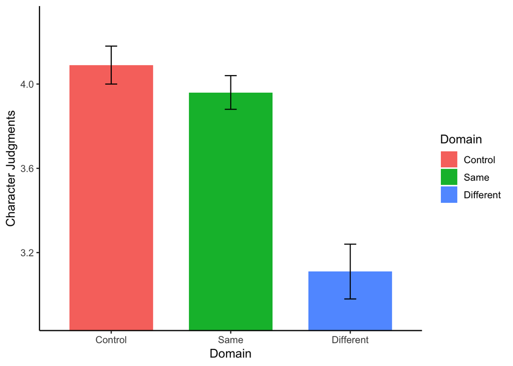

```r
library(ggplot2)
ggplot(kable_anov_domain_char, aes(x=Domain, y=character_judgment_mean, fill=Domain))+
  geom_bar(stat="identity", width = 0.7)+
  coord_cartesian(ylim = c(2.9,4.3))+
  geom_errorbar(aes(ymin = character_judgment_mean+SE,
                    ymax = character_judgment_mean-SE),
                width=0.1)+
  labs(y="Character Judgments")+
  theme_classic(base_size = 12)
```

### Hypothesis 1C: Domain should have a stronger effect on character evaluations than on act evaluations

Mixed ANOVA with factors of Domain (Control, Different) and Judgment Type (act vs. character)

```r
library(dplyr)
df_control_diff <- charExp1 %>%
  filter(charExp1$Domain != "Same")

df_control_diff <- as.data.frame(df_control_diff)

library(tidyverse)
df_control_diff %>%
  tidyr::gather(
    key="judgment_type",
    value="judgment",
    Character_Judgments,
    Act_Judgments
  ) ->
  df.long_domain_judgment

df.long_domain_judgment$Response_ID <- factor(df.long_domain_judgment$Response_ID)
df.long_domain_judgment$judgment_type <- factor(df.long_domain_judgment$judgment_type,
                                                levels =  unique(df.long_domain_judgment$judgment_type))
df.long_domain_judgment$Domain <- factor(df.long_domain_judgment$Domain,
                                         levels = unique(df.long_domain_judgment$Domain))

library(ez)
anov_domain_judgment <- ezANOVA(
  data = df.long_domain_judgment,
  dv = judgment,
  wid = Response_ID,
  within = judgment_type,
  between = Domain,
  type = 3,
  return_aov = TRUE,
  detailed = TRUE
)

kable_anov_domain_judgment <- df_control_diff %>%
  group_by(Domain) %>%
  dplyr::summarise(character_judgment_mean = round(mean(Character_Judgments),digits = 2),
                   character_SE = round((sd(Character_Judgments)/sqrt(length(Character_Judgments))),digits = 2),
                   act_judgment_mean = round(mean(Act_Judgments),digits = 2),
                   act_SE = round((sd(Act_Judgments)/sqrt(length(Act_Judgments))),digits = 2))
knitr::kable(kable_anov_domain_judgment)
```

| Domain | character_judgment_mean | character_SE | act_judgment_mean | act_SE |
| --- | --- | --- | --- | --- |
| Control | 4.09 | 0.09 | 3.76 | 0.10 |
| Different | 3.11 | 0.13 | 3.60 | 0.12 |

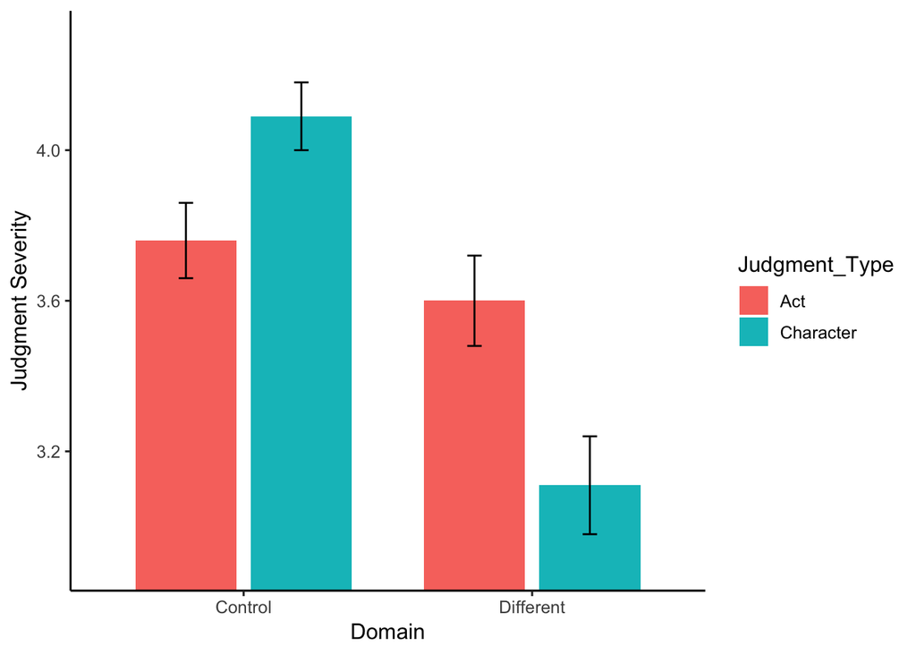

```r
df_anov_domain_judgment <- data.frame(Domain = rep(c("Control","Different"),each=2),
                                      Judgment_Type = factor(rep(c("Character","Act"),times=2)),
                                      Judgment = c(kable_anov_domain_judgment[[2]][1],
                                                   kable_anov_domain_judgment[[4]][1],
                                                   kable_anov_domain_judgment[[2]][2],
                                                   kable_anov_domain_judgment[[4]][2]),
                                      Judgment_SE = c(kable_anov_domain_judgment[[3]][1],
                                                      kable_anov_domain_judgment[[5]][1],
                                                      kable_anov_domain_judgment[[3]][2],
                                                      kable_anov_domain_judgment[[5]][2]))


library(ggplot2)
ggplot(df_anov_domain_judgment, aes(x=Domain, y=Judgment, fill=Judgment_Type))+
  geom_bar(stat="identity", position = position_dodge(width=0.8), width = 0.7)+
  coord_cartesian(ylim = c(2.9,4.3))+
  geom_errorbar(aes(ymin = Judgment+Judgment_SE,
                    ymax = Judgment-Judgment_SE),
                position = position_dodge(width=0.8),
                width=0.1)+
  labs(y="Judgment Severity")+
  theme_classic(base_size = 12)
```

```r
#dat_aov <- summary(aov(judgment ~ judgment_type * Domain + Error(Response_ID/judgment_type), data = df.long_domain_judgment))
```

### Hypothesis 2A: Greater (forced) choice of disgust for control compared to different domain

Chi Square

```r
library(dplyr)
df_control_diff <- charExp1 %>%
  filter(charExp1$Domain != "Same")

df_control_diff <- as.data.frame(df_control_diff)
df_control_diff$Domain <- factor(df_control_diff$Domain)

chisq.test(table(df_control_diff$Domain,
                 df_control_diff$Forced_Face_Choice))
```

```
##
##  Pearson's Chi-squared test with Yates' continuity correction
##
## data:  table(df_control_diff$Domain, df_control_diff$Forced_Face_Choice)
## X-squared = 0.16367, df = 1, p-value = 0.6858
```

```r
table(df_control_diff$Domain,
                 df_control_diff$Forced_Face_Choice)
```

```
##
##              0  1
##   Control   39 19
##   Different 42 16
```

### Hypothesis 2B: Domain should have a stronger effect on disgust than on anger

Mixed ANOVA with factors of Domain and Emotion Type (disgust vs. anger)

```r
library(tidyverse)
df_control_diff %>%
  tidyr::gather(
    key="emotion_type",
    value="emotion",
    Angry_Faces,
    Disgusted_Faces
  ) ->
  df.long_domain_emotion

df.long_domain_emotion$Response_ID <- factor(df.long_domain_emotion$Response_ID)
df.long_domain_emotion$emotion_type <- factor(df.long_domain_emotion$emotion_type,
                                                levels =  unique(df.long_domain_emotion$emotion_type))
df.long_domain_emotion$Domain <- factor(df.long_domain_emotion$Domain,
                                         levels = unique(df.long_domain_emotion$Domain))

library(ez)
anov_domain_emotion <- ezANOVA(
  data = df.long_domain_emotion,
  dv = emotion,
  wid = Response_ID,
  within = emotion_type,
  between = Domain,
  type = 3,
  return_aov = TRUE,
  detailed = TRUE
)

kable_anov_domain_emotion <- df_control_diff %>%
  group_by(Domain) %>%
  dplyr::summarise(disgust_mean = round(mean(Disgusted_Faces),digits = 2),
                   disgust_SE = round((sd(Disgusted_Faces)/sqrt(length(Disgusted_Faces))),digits = 2),
                   anger_mean = round(mean(Angry_Faces),digits = 2),
                   anger_SE = round((sd(Angry_Faces)/sqrt(length(Angry_Faces))),digits = 2))
knitr::kable(kable_anov_domain_emotion)
```

| Domain | disgust_mean | disgust_SE | anger_mean | anger_SE |
| --- | --- | --- | --- | --- |
| Control | 2.57 | 0.15 | 2.97 | 0.15 |
| Different | 2.41 | 0.16 | 2.57 | 0.14 |

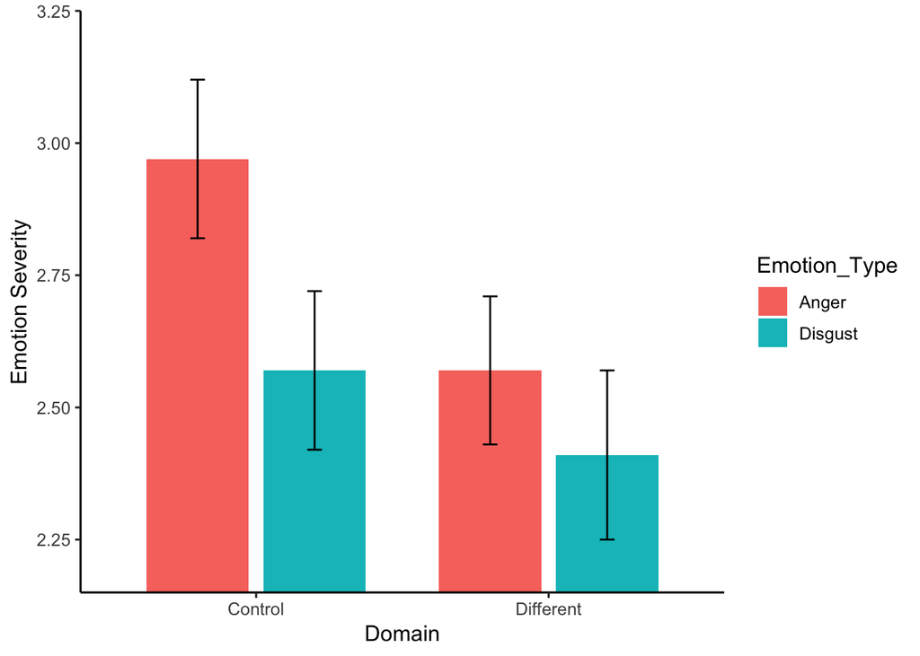

```r
df_anov_domain_emotion <- data.frame(Domain = rep(c("Control","Different"),each=2),
                                      Emotion_Type = factor(rep(c("Disgust","Anger"),times=2)),
                                      Emotion = c(kable_anov_domain_emotion[[2]][1],
                                                   kable_anov_domain_emotion[[4]][1],
                                                   kable_anov_domain_emotion[[2]][2],
                                                   kable_anov_domain_emotion[[4]][2]),
                                      Emotion_SE = c(kable_anov_domain_emotion[[3]][1],
                                                      kable_anov_domain_emotion[[5]][1],
                                                      kable_anov_domain_emotion[[3]][2],
                                                      kable_anov_domain_emotion[[5]][2]))

library(ggplot2)
ggplot(df_anov_domain_emotion, aes(x=Domain, y=Emotion, fill=Emotion_Type))+
  geom_bar(stat="identity", position = position_dodge(width=0.8), width = 0.7)+
  coord_cartesian(ylim = c(2.2,3.2))+
  geom_errorbar(aes(ymin = Emotion+Emotion_SE,
                    ymax = Emotion-Emotion_SE),
                position = position_dodge(width=0.8),
                width=0.1)+
  labs(y="Emotion Severity")+
  theme_classic(base_size = 12)
```

### Hypothesis 3A: Disgust should predict character ratings better than anger ratings

Whole sample multiple regression with disgust and anger ratings as simultaneous IVs and character as the DV. Then test for difference between two dependent betas

```r
lm_emotion_char <- summary(lm(df_control_diff$Character_Judgments ~ df_control_diff$Angry_Faces + df_control_diff$Disgusted_Faces, data = df_control_diff))
lm_emotion_char
```

```
##
## Call:
## lm(formula = df_control_diff$Character_Judgments ~ df_control_diff$Angry_Faces +
##     df_control_diff$Disgusted_Faces, data = df_control_diff)
##
## Residuals:
##     Min      1Q  Median      3Q     Max
## -2.8818 -0.5320  0.1078  0.6762  1.4806
##
## Coefficients:
##                                 Estimate Std. Error t value Pr(>|t|)
## (Intercept)                      2.63768    0.23421  11.262   <2e-16 ***
## df_control_diff$Angry_Faces      0.13655    0.09121   1.497   0.1372
## df_control_diff$Disgusted_Faces  0.23400    0.08549   2.737   0.0072 **
## ---
## Signif. codes:  0 '***' 0.001 '**' 0.01 '*' 0.05 '.' 0.1 ' ' 1
##
## Residual standard error: 0.9075 on 113 degrees of freedom
## Multiple R-squared:  0.1589, Adjusted R-squared:  0.144
## F-statistic: 10.68 on 2 and 113 DF,  p-value: 5.668e-05
```

```r
# t-test for dependent betas (2 IVs)
beta_angry_char <- lm_emotion_char$coefficients[2]
beta_disgust_char <- lm_emotion_char$coefficients[3]
r.sq_emotion_char <- lm_emotion_char$r.squared
n_emotion_char <- length(levels(df.long_domain_emotion$Response_ID))
determ_1 <- 1 - cor_emotion_faces$estimate^2
determ_2 <- 1/determ_1
determ_3 <- -1*cor_emotion_faces$estimate/determ_1
test_df <- n_emotion_char - 3
SE <- sqrt(((1 - r.sq_emotion_char)/(test_df))*(2*determ_2 - 2*determ_3))[[1]]
t_beta_emotion_char <- (beta_angry_char - beta_disgust_char)/SE
p_beta_emotion_char <- pt(-abs(t_beta_emotion_char),test_df)*2
```

### Hypothesis 3B: Both disgust and anger should predict act judgments

Whole sample multiple regression with disgust and anger ratings as simultaneous IVs and act judgments as the DV. Then test for difference between two dependent betas

```r
lm_emotion_act <- summary(lm(df_control_diff$Act_Judgments ~ df_control_diff$Angry_Faces + df_control_diff$Disgusted_Faces, data = df_control_diff))
lm_emotion_act
```

```
##
## Call:
## lm(formula = df_control_diff$Act_Judgments ~ df_control_diff$Angry_Faces +
##     df_control_diff$Disgusted_Faces, data = df_control_diff)
##
## Residuals:
##      Min       1Q   Median       3Q      Max
## -2.22056 -0.39626  0.04552  0.49659  1.38968
##
## Coefficients:
##                                 Estimate Std. Error t value Pr(>|t|)
## (Intercept)                      2.31446    0.17656  13.108  < 2e-16 ***
## df_control_diff$Angry_Faces      0.21914    0.06876   3.187  0.00186 **
## df_control_diff$Disgusted_Faces  0.30512    0.06445   4.734 6.43e-06 ***
## ---
## Signif. codes:  0 '***' 0.001 '**' 0.01 '*' 0.05 '.' 0.1 ' ' 1
##
## Residual standard error: 0.6842 on 113 degrees of freedom
## Multiple R-squared:  0.395,  Adjusted R-squared:  0.3843
## F-statistic: 36.89 on 2 and 113 DF,  p-value: 4.677e-13
```

```r
# t-test for dependent betas (2 IVs)
beta_angry_act <- lm_emotion_act$coefficients[2]
beta_disgust_act <- lm_emotion_act$coefficients[3]
r.sq_emotion_act <- lm_emotion_act$r.squared
n_emotion_act <- length(levels(df.long_domain_emotion$Response_ID))
determ_1 <- 1 - cor_emotion_faces$estimate^2
determ_2 <- 1/determ_1
determ_3 <- -1*cor_emotion_faces$estimate/determ_1
test_df <- n_emotion_act - 3
SE <- sqrt(((1 - r.sq_emotion_act)/(test_df))*(2*determ_2 - 2*determ_3))[[1]]
t_beta_emotion_act <- (beta_angry_act - beta_disgust_act)/SE
p_beta_emotion_act <- pt(-abs(t_beta_emotion_act),test_df)*2
```

# Discussion

This data was first analyzed usign SPSS, and then re-analyzed using the R scripts in this file. The analyses were successfully recreated in R.